# Astrometría I

## Informe de Guia de ejericios 4

### Inferencia Bayesiana con métodos MonteCarlo: Cadenas de Markov

### Introducción

La inferencia estadística se puede llevar a cabo como una aplicación del teorema de Bayes. Si tenemos un conjunto de datos $d$ que se pueden describir por un modelo $m$ con parámetros $\phi$, queremos calcular el mejor modelo que puede dar lugar a esos datos, es decir, maximizar la probabilidad posterior de los parámetros dados los datos para un modelo $m$, $p(\phi|d, m)$. Esta probabilidad es proporcional al Likelihood $p(d|\phi, m)$ por la función distribución de la probabilidad anterior ($prior, p(\phi, m)$).

\begin{equation} p(\phi|d, m) = \frac{p(d|\phi, m) p(\phi|m)}{p(d|m)} \end{equation}

y está normalizada por la evidencia, es decir, la probabilidad marginal del Likelihood para el modelo $m$:

\begin{equation} p(d|m) = \int_\Omega = p(d|\phi, m)p(\phi|m)d\phi \end{equation}

donde $\Omega$ denota el espacio de parámetros.

Cuando se ajusta un modelo a un conjunto de datos, se quiere conocer la función de Likelihood, $p(d|\phi, m)$, que depende de los parámetros $\phi$. Existen varios métodos para llevar esto a cabo, entre ellos las Cadenas de Markov Monte Carlo (MCMC). En particular, el algoritmo de Metrópolis-Hastings es un método de MCMC que se utiliza para simular distribuciones multivariadas.

Para empezar, se importarán los datos con los cuales se trabajará. Se trata de valores correspondientes a la función de luminosidad en base a la magnitud absoluta, y sus respectivos errores.

```python
import numpy as np
import matplotlib.pyplot as plt
import pandas as pd
```

```python
df = pd.read_csv('datos.csv')
```

```python
df
```

|  | MAG | PHI | error_inf | error_sup |
| --- | --- | --- | --- | --- |
| 0 | -23.183 | 0.000003 | 0.000002 | 0.000003 |
| 1 | -23.020 | 0.000005 | 0.000003 | 0.000005 |
| 2 | -22.870 | 0.000017 | 0.000005 | 0.000009 |
| 3 | -22.698 | 0.000035 | 0.000009 | 0.000010 |
| 4 | -22.565 | 0.000082 | 0.000024 | 0.000023 |
| 5 | -22.411 | 0.000122 | 0.000017 | 0.000020 |
| 6 | -22.248 | 0.000241 | 0.000034 | 0.000040 |
| 7 | -22.096 | 0.000328 | 0.000038 | 0.000043 |
| 8 | -21.942 | 0.000504 | 0.000059 | 0.000084 |
| 9 | -21.793 | 0.000933 | 0.000133 | 0.000091 |
| 10 | -21.638 | 0.001269 | 0.000147 | 0.000212 |
| 11 | -21.484 | 0.001725 | 0.000201 | 0.000257 |
| 12 | -21.311 | 0.002573 | 0.000368 | 0.000250 |
| 13 | -21.176 | 0.003191 | 0.000282 | 0.000419 |
| 14 | -21.011 | 0.003834 | 0.000339 | 0.000372 |
| 15 | -20.857 | 0.005056 | 0.000724 | 0.000490 |
| 16 | -20.703 | 0.005539 | 0.000642 | 0.000538 |
| 17 | -20.560 | 0.006456 | 0.000750 | 0.000626 |
| 18 | -20.412 | 0.007296 | 0.000847 | 0.000708 |
| 19 | -20.241 | 0.008502 | 0.000753 | 0.000825 |
| 20 | -20.098 | 0.009608 | 0.001116 | 0.001096 |
| 21 | -19.934 | 0.009897 | 0.001673 | 0.000960 |
| 22 | -19.780 | 0.010844 | 0.001260 | 0.001424 |
| 23 | -19.634 | 0.012255 | 0.001753 | 0.001186 |
| 24 | -19.478 | 0.013019 | 0.001688 | 0.001263 |
| 25 | -19.308 | 0.013409 | 0.001557 | 0.002237 |
| 26 | -19.165 | 0.015628 | 0.002234 | 0.001518 |
| 27 | -19.006 | 0.014676 | 0.001706 | 0.002448 |
| 28 | -18.863 | 0.015118 | 0.001337 | 0.002522 |
| 29 | -18.698 | 0.018170 | 0.002598 | 0.002387 |
| 30 | -18.539 | 0.016542 | 0.001919 | 0.002173 |
| 31 | -18.407 | 0.016024 | 0.002708 | 0.002675 |
| 32 | -18.243 | 0.018673 | 0.002166 | 0.003115 |
| 33 | -18.089 | 0.020778 | 0.003243 | 0.004615 |
| 34 | -17.924 | 0.016981 | 0.002428 | 0.003453 |
| 35 | -17.765 | 0.018604 | 0.003144 | 0.003106 |
| 36 | -17.628 | 0.019768 | 0.004324 | 0.003298 |
| 37 | -17.466 | 0.025271 | 0.004271 | 0.005141 |
| 38 | -17.320 | 0.027690 | 0.004680 | 0.005636 |
| 39 | -17.166 | 0.030341 | 0.005894 | 0.007315 |
| 40 | -17.002 | 0.021581 | 0.005730 | 0.003600 |
| 41 | -16.848 | 0.026753 | 0.008281 | 0.005441 |
| 42 | -16.700 | 0.027560 | 0.009107 | 0.008817 |
| 43 | -16.557 | 0.036340 | 0.010459 | 0.013135 |
| 44 | -16.402 | 0.067273 | 0.017854 | 0.030158 |
| 45 | -16.232 | 0.016250 | 0.010379 | 0.026045 |
| 46 | -16.081 | 0.057516 | 0.027429 | 0.059439 |

Se procede a graficar para obtener una visualización de los datos. Se intenta reproducir la figura de Blanton et. al. (2001).

```python
#se definen los errores para graficarlos
e= [df['error_inf'], df['error_sup']]
```

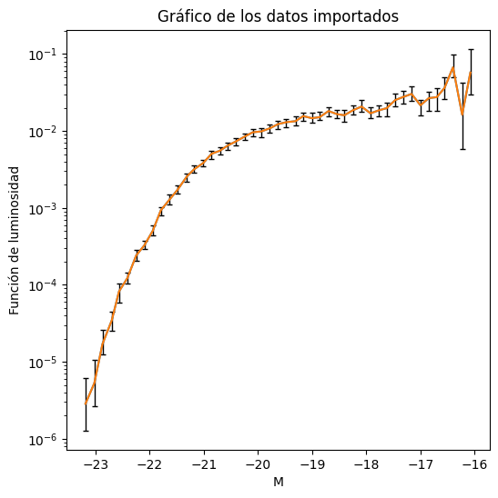

```python
#se grafican los datos con sus errores
plt.figure(figsize=(6,6))
plt.plot(df['MAG'],df['PHI'])
plt.yscale("log")
plt.errorbar(df['MAG'],df['PHI'], yerr = e , ecolor= 'k', elinewidth = 1, capsize = 2 )
plt.xlabel('M')
plt.ylabel('Función de luminosidad')
plt.title('Gráfico de los datos importados')
```

#### Función de Schechter

\begin{equation} \Phi(M)dM= 0.4ln(10) \Phi_* 10^{-0.4(M-M_*)(\alpha+1)} exp(-10^{-0.4(M-M_*)})dM \end{equation}

```python
#se define la funcion de luminosidad de schechter
def sch(M, phi0=1.46*10**(-2), M0=-20.83, alpha0=-1.2):
    phi = 0.4 * np.log(10) * phi0 * 10**(-0.4*(M-M0)*(alpha0+1)) * np.exp(-10**(-0.4*(M-M0)))
    return phi
```

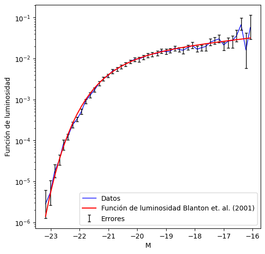

```python
#al grafico anterior se le añade el ajuste de la func de lum
plt.figure(figsize=(6,6))
plt.plot(df['MAG'],df['PHI'], color='b', lw=1, label='Datos')
plt.yscale("log")
plt.errorbar(df['MAG'],df['PHI'], yerr = e, fmt='none', ecolor= 'k', elinewidth = 1, capsize = 2, label='Errores')
plt.xlabel('M')
plt.ylabel('Función de luminosidad')

plt.plot(df['MAG'],sch(df['MAG']), color='red', label='Función de luminosidad Blanton et. al. (2001)')
plt.legend()
```

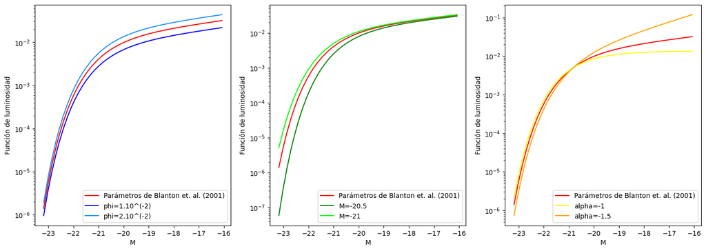

```python
#se testea la funcion de schechter variando los parámetros uno a la vez:
plt.figure(figsize=(18,6))
plt.subplot(1,3,1)
plt.plot(df['MAG'],sch(df['MAG']), color='red', label='Parámetros de Blanton et. al. (2001)')
plt.plot(df['MAG'],sch(df['MAG'], phi0=1.*10**(-2), M0=-20.83, alpha0=-1.2), color='blue', label='phi=1.10^(-2)')
plt.plot(df['MAG'],sch(df['MAG'], phi0=2.*10**(-2), M0=-20.83, alpha0=-1.2), color='dodgerblue', label='phi=2.10^(-2)')
plt.yscale("log")
plt.xlabel('M')
plt.ylabel('Función de luminosidad')
plt.legend()

plt.subplot(1,3,2)
plt.plot(df['MAG'],sch(df['MAG']), color='red', label='Parámetros de Blanton et. al. (2001)')
plt.plot(df['MAG'],sch(df['MAG'], phi0=1.46*10**(-2), M0=-20.5, alpha0=-1.2), color='g', label='M=-20.5')
plt.plot(df['MAG'],sch(df['MAG'], phi0=1.46*10**(-2), M0=-21., alpha0=-1.2), color='lime', label='M=-21')
plt.yscale("log")
plt.xlabel('M')
plt.ylabel('Función de luminosidad')
plt.legend()

plt.subplot(1,3,3)
plt.plot(df['MAG'],sch(df['MAG']), color='red', label='Parámetros de Blanton et. al. (2001)')
plt.plot(df['MAG'],sch(df['MAG'], phi0=1.46*10**(-2), M0=-20.83, alpha0=-1.), color='yellow', label='alpha=-1')
plt.plot(df['MAG'],sch(df['MAG'], phi0=1.46*10**(-2), M0=-20.83, alpha0=-1.5), color='orange', label='alpha=-1.5')
plt.yscale("log")
plt.xlabel('M')
plt.ylabel('Función de luminosidad')
plt.legend()
```

A continuación se desea ajustar el modelo $m$ al conjunto de datos $d$, mediante un análisis Bayesiano. Para el caso de nuestros datos, se utilizará como modelo la función de Schechter.

Los parámetros que se intentan determinar son $\phi_*$, $M_∗$ y $\alpha$. Para ello, se construirán las siguientes funciones:

- la función de likelihood
- la función de priors
- la función de probabilidad posterior

Estas funciones se necesitarán cuando se explore el espacio de parámetros.

##### Likelihood

La funión de Likelihooh indica qué tan bien reproducen los datos a las predicciones del modelo. En este caso se trabajará con el logaritmo del likelihood y de este modo lo que se intentará es minimizar su valor.

```python
#se define un error simétrico para utilizar como sigma
error = (df['error_sup'] + df['error_inf'])/2.
```

```python
#se define la version de funcion de likelihood a minimizar
#recordar que se quiere maximizar el likelihood pero eso implica minimizar este termino
#el otro termino del likelihood se despreció porque era constante
#se trabaja con log del likelihood
def max_LH(model, x=df['PHI'], sigma=error):
    L = np.sum(((x-model) / sigma)**2)
    return L
```

```python
#se quiere minimizar este valor, esto seria como maximizar el likelihood
max_LH(sch(df['MAG']))
```

```
29.718759919064347
```

##### Priors

Los priors son la información previa que se tiene sobre el modelo. En este caso, se estimaron los valores límites de los parámetros del modelo variando los parámetros y observando gráficamente.

```python
#se definen los priors
#se trabaja con el log
def prior(param, lim_inf, lim_sup):
    if param[0] > lim_inf[0] and param[0] < lim_sup[0] and param[1] > lim_inf[1] and param[1] < lim_sup[1] and param[2] > lim_inf[2] and param[2] < lim_sup[2]:
        return 0
    else:
        return -np.inf
```

```python
#se define la lista param con valores para phi, M y alpha en ese orden
param = [1.5*10**(-2), -20.6, -1.4]
```

```python
#se definen los rangos para cada paramentro en orden:
lim_inf = [1*10**(-2), -21, -1.5]
lim_sup = [2*10**(-2), -20.5, -1]
```

```python
#se prueba un prior con los valores dados en param
prior(param, lim_inf, lim_sup)
```

```
0
```

##### Probabilidad Posteriori

```python
#se define la posteriori
#se trabaja con el log
def post(model, param):
    P = max_LH(model) + prior(param, lim_inf, lim_sup)
    return P
```

```python
#se prueba la posteriori
post(sch(df['MAG'], param[0], param[1], param[2]), param)
```

```
459.8586388786661
```

```python
#se define una funcion para Metropolis Hastings
def MH(N=1000, t=100):  #N es la cantidad de saltos,
                        #t es la division del intervalo para el tamaño de los saltos

    #matriz vacia para guardar los saltos
    parametros = np.zeros((N, 3))

    #se definen condiciones iniciales aleatorias
    parametros[0] = np.random.rand(1,3) #valores aleatorios entre 0 y 1
    #se llevan estos num aleatorios a valores aleatorios entre los intervalos para cada parametro
    # al mismo tiempo se define el tamaño de los saltos
    tamaño_salto = []
    for i in (0, 1, 2):
        parametros[0][i] = parametros[0][i]* (lim_sup[i] - lim_inf[i]) + lim_inf[i]
        t_s = (lim_sup[i] - lim_inf[i]) / t
        tamaño_salto.append(t_s)

    #se calcula un salto en los parametros y se guarda el resultado
    #el tamaño del salto es aleatorio (y hacia adelante o atras)
    #pero tiene como tamaño de salto maximo el tamaño definido hace rato
    for i in range(0,N-1):
        parametros[i+1][0] = parametros[i][0] + (np.random.rand()*2-1) * tamaño_salto[0]
        parametros[i+1][1] = parametros[i][1] + (np.random.rand()*2-1) * tamaño_salto[1]
        parametros[i+1][2] = parametros[i][2] + (np.random.rand()*2-1) * tamaño_salto[2]

    #se calcula el r como resta de las probabilidades (es resta porque se trabaja en log)
        vieja = post(sch(df['MAG'], parametros[i][0], parametros[i][1], parametros[i][2]), parametros[i])
        nueva = post(sch(df['MAG'], parametros[i+1][0], parametros[i+1][1], parametros[i+1][2]), parametros[i+1])

        r = vieja - nueva

        if np.exp(r) >= 1:
            pass  #se acepta
        else:
            r=np.exp(r)
            random = np.random.rand()
            if random < r:
                pass #se acepta
            else:   #se rechaza
                parametros[i+1][0] = parametros[i][0]
                parametros[i+1][1] = parametros[i][1]
                parametros[i+1][2] = parametros[i][2]

    return parametros
```

```python
#funcion con 5000 pasos
saltos = MH(5000)
```

```python
saltos
```

```
array([[ 1.00738773e-02, -2.07416402e+01, -1.36201897e+00],
       [ 1.01543428e-02, -2.07397519e+01, -1.35797153e+00],
       [ 1.01543428e-02, -2.07397519e+01, -1.35797153e+00],
       ...,
       [ 1.49395898e-02, -2.07822067e+01, -1.17461882e+00],
       [ 1.49628709e-02, -2.07857413e+01, -1.17708677e+00],
       [ 1.49628709e-02, -2.07857413e+01, -1.17708677e+00]])
```

```python
#se redefine una lista para cada parametro
salto_phi = saltos[:,0]
salto_M = saltos[:,1]
salto_alpha = saltos[:,2]
```

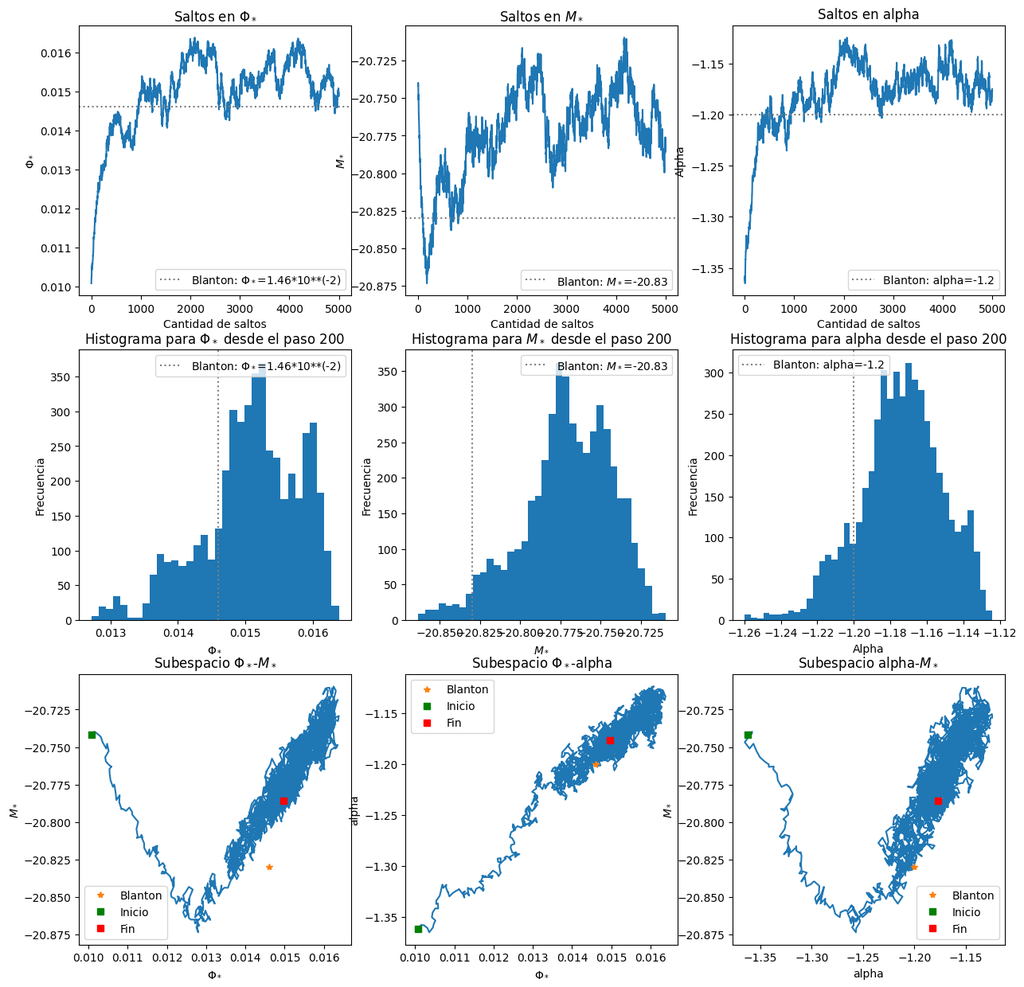

```python
#se analizan las cadenas con varios graficos
plt.figure(figsize=(15,15))

plt.subplot(3,3,1)
plt.plot(salto_phi)
plt.axhline(1.46*10**(-2), color='grey', label='Blanton: $\Phi_*$=1.46*10**(-2)', ls="dotted")
plt.title('Saltos en $\Phi_*$')
plt.xlabel('Cantidad de saltos')
plt.ylabel('$\Phi_*$')
plt.legend()

plt.subplot(3,3,2)
plt.plot(salto_M)
plt.axhline(-20.83, color='grey', label='Blanton: $M_*$=-20.83', ls="dotted")
plt.title('Saltos en $M_*$')
plt.xlabel('Cantidad de saltos')
plt.ylabel('$M_*$')
plt.legend()

plt.subplot(3,3,3)
plt.plot(salto_alpha)
plt.axhline(-1.2, color='grey', label='Blanton: alpha=-1.2', ls="dotted")
plt.title('Saltos en alpha')
plt.xlabel('Cantidad de saltos')
plt.ylabel('Alpha')
plt.legend()

plt.subplot(3,3,4)
plt.hist(salto_phi[200:], bins='auto')
plt.axvline(1.46*10**(-2), color='grey', label='Blanton: $\Phi_*$=1.46*10**(-2)', ls="dotted")
plt.title('Histograma para $\Phi_*$ desde el paso 200')
plt.xlabel('$\Phi_*$')
plt.ylabel('Frecuencia')
plt.legend()

plt.subplot(3,3,5)
plt.hist(salto_M[200:], bins='auto')
plt.axvline(-20.83, color='grey', label='Blanton: $M_*$=-20.83', ls="dotted")
plt.title('Histograma para $M_*$ desde el paso 200')
plt.xlabel('$M_*$')
plt.ylabel('Frecuencia')
plt.legend()

plt.subplot(3,3,6)
plt.hist(salto_alpha[200:], bins='auto')
plt.axvline(-1.2, color='grey', label='Blanton: alpha=-1.2', ls="dotted")
plt.title('Histograma para alpha desde el paso 200')
plt.xlabel('Alpha')
plt.ylabel('Frecuencia')
plt.legend()

plt.subplot(3,3,7)
plt.plot(salto_phi, salto_M)
plt.plot(1.46*10**(-2), -20.83, '*', label='Blanton')
plt.plot(salto_phi[0], salto_M[0], 's', color='green', label='Inicio')
plt.plot(salto_phi[-1], salto_M[-1], 's', color='red', label='Fin')
plt.title('Subespacio $\Phi_*$-$M_*$')
plt.xlabel('$\Phi_*$')
plt.ylabel('$M_*$')
plt.legend()

plt.subplot(3,3,8)
plt.plot(salto_phi, salto_alpha)
plt.plot(1.46*10**(-2), -1.2, '*', label='Blanton')
plt.plot(salto_phi[0], salto_alpha[0], 's', color='green', label='Inicio')
plt.plot(salto_phi[-1], salto_alpha[-1], 's', color='red', label='Fin')
plt.title('Subespacio $\Phi_*$-alpha')
plt.xlabel('$\Phi_*$')
plt.ylabel('alpha')
plt.legend()

plt.subplot(3,3,9)
plt.plot(salto_alpha, salto_M)
plt.plot(-1.2, -20.83, '*', label='Blanton')
plt.plot(salto_alpha[0], salto_M[0], 's', color='green', label='Inicio')
plt.plot(salto_alpha[-1], salto_M[-1], 's', color='red', label='Fin')
plt.title('Subespacio alpha-$M_*$')
plt.xlabel('alpha')
plt.ylabel('$M_*$')
plt.legend()
```

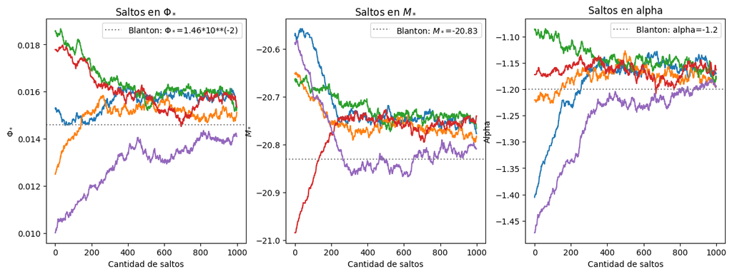

```python
#vamos a repetir muchas cadenas una cantidad de veces R
R=5
cadena=[]
cadena_phi=[]
cadena_M=[]
cadena_alpha=[]

for i in range(0,R):
    c = MH()
    c_phi = c[:,0]
    c_M = c[:,1]
    c_alpha = c[:,2]
    cadena.append(c)
    cadena_phi.append(c_phi)
    cadena_M.append(c_M)
    cadena_alpha.append(c_alpha)

plt.figure(figsize=(15,5))
plt.subplot(1,3,1)
for i in range(0,R):
    plt.plot(cadena_phi[i])
plt.axhline(1.46*10**(-2), color='grey', label='Blanton: $\Phi_*$=1.46*10**(-2)', ls="dotted")
plt.title('Saltos en $\Phi_*$')
plt.xlabel('Cantidad de saltos')
plt.ylabel('$\Phi_*$')
plt.legend()

plt.subplot(1,3,2)
for i in range(0,R):
    plt.plot(cadena_M[i])
plt.axhline(-20.83, color='grey', label='Blanton: $M_*$=-20.83', ls="dotted")
plt.title('Saltos en $M_*$')
plt.xlabel('Cantidad de saltos')
plt.ylabel('$M_*$')
plt.legend()

plt.subplot(1,3,3)
for i in range(0,R):
    plt.plot(cadena_alpha[i])
plt.axhline(-1.2, color='grey', label='Blanton: alpha=-1.2', ls="dotted")
plt.title('Saltos en alpha')
plt.xlabel('Cantidad de saltos')
plt.ylabel('Alpha')
plt.legend()
```

## Método de Gradiente Descendente

```python
#se define la funcion chi cuadrado
def chi2():
    for i in range(0, len(df['MAG'])):
        test=np.sum(((df['PHI'][i]-sch(df['MAG'])[i]) /error[i])**2)
    return(test)
```

```python
#se prueba la funcion
chi2()
```

```
0.34925253743298373
```

```python
#defino la derivada respecto a phi de la func de lum
def Dphi0(M, phi0=1.46*10**(-2), M0=-20.83, alpha0=-1.2):
    dphi = 0.4 * np.log(10) * 10**(-0.4*(M-M0)*(alpha0+1)) * np.exp(-10**(-0.4*(M-M0)))
    return dphi
```

```python
#defino la derivada respecto a M de la func de lum
def DM0(M, phi0=1.46*10**(-2), M0=-20.83, alpha0=-1.2):
    A = 0.4 * np.log(10) * phi0
    B = 10**(-0.4*(M-M0)*(alpha0+1))
    C = np.exp(-10**(-0.4*(M-M0)))
    T1 = np.log(10) * B * 0.4 * (alpha0+1) * C
    T2 = B * C * 0.4 * np.log(10) * (-10**(-0.4*(M-M0)))
    dM = A * (T1 + T2)
    return dM
```

```python
#defino la derivada respecto a alpha de la func de lum
def Dalpha0(M, phi0=1.46*10**(-2), M0=-20.83, alpha0=-1.2):
    dphi = 0.4 * np.log(10) * phi0 * np.log(10) * 10**(-0.4*(M-M0)*(alpha0+1)) * (-0.4) * (M-M0) * np.exp(-10**(-0.4*(M-M0)))
    return dphi
```

```python
#defino el gradiente de chi cuadrado
def gradiente(y=df['PHI'], model=sch(df['MAG']), sigma=error):

    gradiente1= -np.sum(((y-model) /sigma**2) * Dphi0(df['MAG']))
    gradiente2= -np.sum(((y-model) /sigma**2) * DM0(df['MAG']))
    gradiente3= -np.sum(((y-model) /sigma**2) * Dalpha0(df['MAG']))

    norma = np.sqrt(gradiente1**2 + gradiente2**2 + gradiente3**2)
    grad = (gradiente1, gradiente2, gradiente3)
    grad_norm = grad/norma

    return (grad, grad_norm )
```

```python
#pruebo los parametros de Blanton
gradiente()
```

```
((8265.478150519957, -222.4626399596066, -26.444174780037066),
 array([ 0.99963288, -0.02690479, -0.00319818]))
```

```python
#gradiente normalizado:
gradiente()[1]
```

```
array([ 0.99963288, -0.02690479, -0.00319818])
```

```python
#pruebo un phi0=1.*10**(-2)
gradiente(model=sch(df['MAG'], phi0=1.*10**(-2), M0=-20.83, alpha0=-1.2))
```

```
((-43256.0489837664, 660.3333385706397, 487.5027432869221),
 array([-0.99982002,  0.01526294,  0.01126814]))
```

```python
#pruebo un phi0=1.5*10**(-2)
gradiente(model=sch(df['MAG'], phi0=1.5*10**(-2), M0=-20.83, alpha0=-1.2))
```

```
((12745.610944805725, -299.2275076578888, -71.13521113368573),
 array([ 0.99970897, -0.02347007, -0.00557953]))
```

```python
#se define la funcion gradiente descendente
def grad_desc(S=100, eta=0.1):
    param0 = np.zeros((S,3))
    L0 = []

    param0[0]=np.random.rand(1,3)
    param0[0][0] = param0[0][0]* (lim_sup[0] - lim_inf[0]) + lim_inf[0]
    param0[0][1] = param0[0][1]* (lim_sup[1] - lim_inf[1]) + lim_inf[1]
    param0[0][2] = param0[0][2]* (lim_sup[2] - lim_inf[2]) + lim_inf[2]

    for i in range(S-1):
        grad = gradiente(model=sch(df['MAG'], phi0=param0[i][0], M0=param0[i][1], alpha0=param0[i][2]))[1]
        param0[i+1] = param0[i] - (eta) * np.abs(grad)

        LK = max_LH(sch(df['MAG'], phi0=param0[i][0], M0=param0[i][1], alpha0=param0[i][2]))
        L0.append(LK)

    return (param0,L0)
```

```python
ptros = grad_desc()[0]    #parametros por paso
lkhds = grad_desc()[1]    #valor de likelihood(simplificado) por paso
```

```python
#se redefinen listas para cada uno delos parametros
_phi = ptros[:,0]
_M = ptros[:,1]
_alpha = ptros[:,2]
```

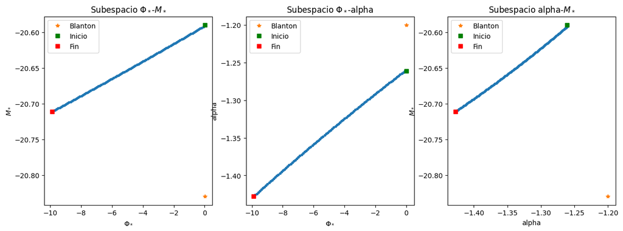

```python
#se grafica las cadenas del metodo de gradiente descendente
plt.figure(figsize=(15,5))

plt.subplot(1,3,1)
plt.plot(_phi, _M, '.')
plt.plot(1.46*10**(-2), -20.83, '*', label='Blanton')
plt.plot(_phi[0], _M[0], 's', color='green', label='Inicio')
plt.plot(_phi[-1], _M[-1], 's', color='red', label='Fin')
plt.title('Subespacio $\Phi_*$-$M_*$')
plt.xlabel('$\Phi_*$')
plt.ylabel('$M_*$')
plt.legend()

plt.subplot(1,3,2)
plt.plot(_phi, _alpha, '.')
plt.plot(1.46*10**(-2), -1.2, '*', label='Blanton')
plt.plot(_phi[0], _alpha[0], 's', color='green', label='Inicio')
plt.plot(_phi[-1], _alpha[-1], 's', color='red', label='Fin')
plt.title('Subespacio $\Phi_*$-alpha')
plt.xlabel('$\Phi_*$')
plt.ylabel('alpha')
plt.legend()

plt.subplot(1,3,3)
plt.plot(_alpha, _M, '.')
plt.plot(-1.2, -20.83, '*', label='Blanton')
plt.plot(_alpha[0], _M[0], 's', color='green', label='Inicio')
plt.plot(_alpha[-1], _M[-1], 's', color='red', label='Fin')
plt.title('Subespacio alpha-$M_*$')
plt.xlabel('alpha')
plt.ylabel('$M_*$')
plt.legend()
```

```python
#plt.contour(X,Y,Z) #se deja uno fijo
#plt.contourf tambien
#plt.colorbar()
```